# Random_motors

```python
import pandas as pd
import os
```

```python
os.getcwd()
```

```
'C:\\Users\\Harusha B\\Documents\\Application of software'
```

```python
os.chdir("C:\\Users\\Harusha B\\Documents\\Application of software")
```

```python
os.getcwd()
```

```
'C:\\Users\\Harusha B\\Documents\\Application of software'
```

```python
df = pd.read_excel("Exhibit+1.xlsx")
df
```

|  | Rocinante 36_Car No. | Rocinante 36_Mileage (km/ltr) | Rocinante 36_Top speed (km/hr) | Marengo 32_Car No. | Marengo 32_Mileage (km/ltr) | Marengo 32_Top speed (km/hr) |
| --- | --- | --- | --- | --- | --- | --- |
| 0 | 1 | 21.20 | 151.9 | 1 | 15.04 | 211.3 |
| 1 | 2 | 21.79 | 147.6 | 2 | 15.41 | 207.0 |
| 2 | 3 | 21.87 | 145.6 | 3 | 15.43 | 206.2 |
| 3 | 4 | 22.71 | 136.1 | 4 | 15.92 | 213.4 |
| 4 | 5 | 22.52 | 139.7 | 5 | 15.20 | 204.2 |
| 5 | 6 | 21.41 | 146.1 | 6 | 15.22 | 208.7 |
| 6 | 7 | 22.71 | 139.6 | 7 | 14.60 | 200.0 |
| 7 | 8 | 21.71 | 143.0 | 8 | 14.41 | 210.9 |
| 8 | 9 | 19.95 | 136.4 | 9 | 14.79 | 208.5 |
| 9 | 10 | 20.65 | 146.6 | 10 | 14.81 | 214.2 |
| 10 | 11 | 22.86 | 139.9 | 11 | 15.61 | 215.8 |
| 11 | 12 | 21.12 | 136.6 | 12 | 15.76 | 215.8 |
| 12 | 13 | 22.80 | 148.5 | 13 | 14.97 | 215.2 |
| 13 | 14 | 20.89 | 143.4 | 14 | 14.71 | 218.7 |
| 14 | 15 | 22.49 | 134.2 | 15 | 15.55 | 208.0 |
| 15 | 16 | 20.94 | 140.5 | 16 | 15.19 | 212.2 |
| 16 | 17 | 20.37 | 137.8 | 17 | 15.36 | 219.7 |
| 17 | 18 | 22.72 | 135.1 | 18 | 15.93 | 216.4 |
| 18 | 19 | 20.54 | 138.8 | 19 | 14.54 | 205.8 |
| 19 | 20 | 21.14 | 132.0 | 20 | 14.76 | 209.0 |

### Q-1) Formulate the null and alternative hypotheses for mileage and top speed to check whether the new models are performing as per the desired design specifications.

### Q-2) In order to comment on whether or not the design specifications are being matched, perform relevant hypothesis tests and calculate the p-values for each model. What will you conclude? Assume that you are performing the tests at a 95% confidence level

### Rocinante36 model - Mileage

### NULL HYPOTHESIS: Mileage HO : Milage of Rocinante36 model is equal to 22km/hr

### ALTERNATE HYPOTHESIS: Mileage H1 : Milage of Rocinante36 model is not equal to 22km/hr

```python
R_Desired_milage = 22
```

```python
R_mileage_data = df["Rocinante 36_Mileage (km/ltr)"]
```

```python
import numpy as np
from scipy import stats
t,p = stats.ttest_1samp(R_mileage_data, R_Desired_milage)
print('t-statistic: ',t)
print('p-value: ',p)
```

```
t-statistic:  -1.8350746065984094
p-value:  0.08220024707686456
```

### Result: AS p-value is greater than 0.05, Fail to reject the null hypothesis: The mileage of Rocinante 36 model is not significantly different from the desired specification.

### Rocinante36 model - Top Speed

### NULL HYPOTHESIS: Top Speed HO : The top speed of Rocinante36 model is equal to 140km/hr

### ALTERNATE HYPOTHESIS: Top Speed H1 : The top speed of Rocinante36 model is not equal to 140km/hr

```python
R_desired_topspeed = 140
```

```python
R_Topspeed_data = df["Rocinante 36_Top speed (km/hr)"]
```

```python
t,p = stats.ttest_1samp(R_Topspeed_data, R_desired_topspeed)
print('t-statistic: ',t)
print('p-value: ',p)
```

```
t-statistic:  0.803602305363553
p-value:  0.43156615071637905
```

### Result: AS p-value is greater than 0.05, Fail to reject the null hypothesis: The Top speed is not significantly different from the desired specification.

### Marengo32 - Mileage

### NULL HYPOTHESIS: Mileage HO : Milage of Marengo32 model is equal to desired mileage

### ALTERNATE HYPOTHESIS: Mileage H1 : Milage of Marengo32 model is not equal to desired mileage

```python
M_Desired_Mileage = 15
M_mileage_data = df["Marengo 32_Mileage (km/ltr)"]
```

```python
t,p = stats.ttest_1samp(M_mileage_data, M_Desired_Mileage)
print('t-statistic: ',t)
print('p-value: ',p)
```

```
t-statistic:  1.5644592519493412
p-value:  0.13421298678380816
```

### Result: AS p-value is greater than 0.05, Fail to reject the null hypothesis: The mileage of Marengo 32 model is not significantly different from the desired specification.

### Marengo 32 model - Top Speed

### NULL HYPOTHESIS: Top Speed HO : The top speed of Marengo 32 model is equal to desired top speed

### ALTERNATE HYPOTHESIS: Top Speed H1 : The top speed of Marengo 32 model is not equal to desired top speed

```python
M_desired_topspeed = 210
M_Topspeed_data = df["Marengo 32_Top speed (km/hr)"]
```

```python
t,p = stats.ttest_1samp(M_Topspeed_data, M_desired_topspeed)
print('t-statistic: ',t)
print('p-value: ',p)
```

```
t-statistic:  0.9124445171733968
p-value:  0.3729676712183989
```

### Result: AS p-value is greater than 0.05, Fail to reject the null hypothesis: The Top speed of Marengo 32 model is not significantly different from the desired specification.

### INTERFERENCE : The Mileage and Top speed of Rocinante36 and Marengo 32 are not significantly differ from desired specification.

### Q-3) You have already learnt about the possible errors that might result from hypothesis tests. Which type of error is more expensive for Random Motors, and why? Assume that you need to refund the money to all your customers if your cars do not deliver the promised specifications.

### The type of error which is more expensive: Type II Error (Failing to reject a false null hypothesis)is more expensive for Random Motors

### REASON: It would result in allowing cars that do not meet specifications to be sold, leading to refunds, loss of reputation, and customer dissatisfaction.

### Q-4) Develop a regression equation for each model at a 95% confidence level. Using the regression equation, predict the sales of the two models. State the hypothesis assumption for the overall test and individual variables.

```python
df1 = pd.read_excel("Exhibit+2.xlsx", sheet_name='Rocinante Models')
df2 = pd.read_excel("Exhibit+2.xlsx", sheet_name='Marengo Models')
```

```python
df1
```

|  | Cars | Sales \n(in 1,000 units) | Price\n(in lakh rupees) | Mileage\n(Km/ltr) | Top speed (Km/hr) |
| --- | --- | --- | --- | --- | --- |
| 0 | Rocinante 1 | 171.877 | 6.1 | 15.8 | 168.2 |
| 1 | Rocinante 2 | 139.796 | 6.1 | 12.1 | 149.6 |
| 2 | Rocinante 3 | 178.947 | 9.9 | 17.0 | 173.4 |
| 3 | Rocinante 4 | 140.022 | 5.8 | 11.6 | 170.6 |
| 4 | Rocinante 5 | 186.476 | 10.0 | 17.2 | 175.0 |
| 5 | Rocinante 6 | 192.123 | 6.5 | 17.6 | 173.1 |
| 6 | Rocinante 7 | 175.085 | 5.5 | 16.0 | 184.6 |
| 7 | Rocinante 8 | 146.882 | 8.4 | 13.0 | 175.7 |
| 8 | Rocinante 9 | 202.847 | 6.6 | 19.3 | 166.7 |
| 9 | Rocinante 10 | 149.933 | 8.8 | 13.3 | 175.4 |
| 10 | Rocinante 11 | 171.579 | 9.5 | 15.8 | 150.9 |
| 11 | Rocinante 12 | 201.512 | 9.2 | 19.2 | 140.5 |
| 12 | Rocinante 13 | 142.604 | 8.1 | 11.7 | 150.2 |
| 13 | Rocinante 14 | 135.158 | 5.4 | 11.2 | 146.2 |
| 14 | Rocinante 15 | 107.322 | 5.6 | 7.8 | 151.2 |
| 15 | Rocinante 16 | 199.699 | 6.3 | 19.0 | 143.2 |
| 16 | Rocinante 17 | 202.875 | 5.8 | 19.7 | 178.9 |
| 17 | Rocinante 18 | 204.406 | 7.7 | 19.5 | 168.2 |
| 18 | Rocinante 19 | 107.331 | 7.2 | 7.5 | 164.7 |
| 19 | Rocinante 20 | 190.345 | 8.4 | 18.1 | 182.7 |
| 20 | Rocinante 21 | 108.419 | 8.4 | 7.9 | 165.7 |
| 21 | Rocinante 22 | 150.249 | 5.7 | 12.6 | 137.0 |
| 22 | Rocinante 23 | 155.882 | 5.5 | 12.9 | 173.9 |
| 23 | Rocinante 24 | 100.980 | 8.4 | 7.6 | 165.1 |
| 24 | Rocinante 25 | 182.679 | 5.6 | 16.7 | 160.1 |
| 25 | Rocinante 26 | 166.752 | 9.9 | 15.5 | 155.6 |
| 26 | Rocinante 27 | 121.561 | 6.2 | 9.5 | 155.4 |
| 27 | Rocinante 28 | 174.256 | 9.9 | 16.3 | 161.9 |
| 28 | Rocinante 29 | 119.018 | 6.5 | 9.1 | 146.8 |
| 29 | Rocinante 30 | 169.842 | 7.1 | 15.3 | 149.5 |
| 30 | Rocinante 31 | 198.311 | 9.6 | 19.1 | 146.5 |
| 31 | Rocinante 32 | 204.875 | 5.8 | 19.4 | 178.9 |
| 32 | Rocinante 33 | 119.561 | 6.2 | 9.4 | 175.4 |
| 33 | Rocinante 34 | 203.875 | 5.9 | 19.4 | 175.9 |
| 34 | Rocinante 35 | 118.561 | 6.1 | 9.4 | 165.4 |

```python
list(df1)
```

```
['Cars',
 'Sales \n(in 1,000 units)',
 'Price\n(in lakh rupees)',
 'Mileage\n(Km/ltr)',
 'Top speed (Km/hr)']
```

## Fitting Regression equation for Rocinante Models

```python
import statsmodels.api as sm

X = df1[['Price\n(in lakh rupees)','Mileage\n(Km/ltr)', 'Top speed (Km/hr)']]

# Add a constant term (intercept) to the model
X = sm.add_constant(X)

# Define the dependent variable (response)
y = df1['Sales \n(in 1,000 units)']

# Fit the regression model
model = sm.OLS(y, X).fit()

# Print the summary of the regression model
model.summary()
```

OLS Regression Results

| Dep. Variable: | Sales (in 1,000 units) | R-squared: | 0.996 |
| --- | --- | --- | --- |
| Model: | OLS | Adj. R-squared: | 0.995 |
| Method: | Least Squares | F-statistic: | 2430. |
| Date: | Fri, 25 Oct 2024 | Prob (F-statistic): | 7.45e-37 |
| Time: | 20:48:44 | Log-Likelihood: | -76.809 |
| No. Observations: | 35 | AIC: | 161.6 |
| Df Residuals: | 31 | BIC: | 167.8 |
| Df Model: | 3 |  |  |
| Covariance Type: | nonrobust |  |  |

|  | coef | std err | t | P>\|t\| | [0.025 | 0.975] |
| --- | --- | --- | --- | --- | --- | --- |
| const | 50.7231 | 5.292 | 9.585 | 0.000 | 39.930 | 61.516 |
| Price (in lakh rupees) | -0.7950 | 0.254 | -3.126 | 0.004 | -1.314 | -0.276 |
| Mileage (Km/ltr) | 8.3063 | 0.100 | 82.913 | 0.000 | 8.102 | 8.511 |
| Top speed (Km/hr) | -0.0186 | 0.031 | -0.608 | 0.548 | -0.081 | 0.044 |

| Omnibus: | 2.817 | Durbin-Watson: | 1.655 |
| --- | --- | --- | --- |
| Prob(Omnibus): | 0.245 | Jarque-Bera (JB): | 2.103 |
| Skew: | 0.600 | Prob(JB): | 0.349 |
| Kurtosis: | 3.030 | Cond. No. | 2.23e+03 |

Notes:  
[1] Standard Errors assume that the covariance matrix of the errors is correctly specified.  
[2] The condition number is large, 2.23e+03. This might indicate that there are  
strong multicollinearity or other numerical problems.

```python
Sales= 50.7231 - 0.7950 * 7 +8.3063 * 22  - 0.0186 * 140
print(Sales)
```

```
225.2927
```

### Regression equation : Sales=50.7231−0.7950×Price+8.3063×Mileage−0.0186×Top Speed

### Predicted sales for Rocinante36 model is 225.2927 units

### but p-value of top speed is greater than 0.05, indicating that top speed is not a statistically significant predictor of sales at the 95% confidence level.

### Overall Significance:

#### The F-statistic of 2430 is exceptionally high. This strongly suggests that your regression model explains a significant amount of the variability in the dependent variable.

### Individual variable

#### Significant Variables: Price and Mileage are significant predictors of the dependent variable. Non-significant Variable: Top speed is not a significant predictor and may not contribute meaningfully to the model.

### Fitting the regression equation by conisdering price and milage variables

```python
X = df1[['Price\n(in lakh rupees)','Mileage\n(Km/ltr)']]

# Add a constant term (intercept) to the model
X = sm.add_constant(X)

# Define the dependent variable (response)
y = df1['Sales \n(in 1,000 units)']

# Fit the regression model
model = sm.OLS(y, X).fit()

# Print the summary of the regression model
model.summary()
```

OLS Regression Results

| Dep. Variable: | Sales (in 1,000 units) | R-squared: | 0.996 |
| --- | --- | --- | --- |
| Model: | OLS | Adj. R-squared: | 0.995 |
| Method: | Least Squares | F-statistic: | 3718. |
| Date: | Fri, 25 Oct 2024 | Prob (F-statistic): | 1.29e-38 |
| Time: | 20:50:31 | Log-Likelihood: | -77.017 |
| No. Observations: | 35 | AIC: | 160.0 |
| Df Residuals: | 32 | BIC: | 164.7 |
| Df Model: | 2 |  |  |
| Covariance Type: | nonrobust |  |  |

|  | coef | std err | t | P>\|t\| | [0.025 | 0.975] |
| --- | --- | --- | --- | --- | --- | --- |
| const | 47.7800 | 2.113 | 22.608 | 0.000 | 43.475 | 52.085 |
| Price (in lakh rupees) | -0.7829 | 0.251 | -3.119 | 0.004 | -1.294 | -0.272 |
| Mileage (Km/ltr) | 8.2945 | 0.097 | 85.257 | 0.000 | 8.096 | 8.493 |

| Omnibus: | 1.906 | Durbin-Watson: | 1.656 |
| --- | --- | --- | --- |
| Prob(Omnibus): | 0.386 | Jarque-Bera (JB): | 1.567 |
| Skew: | 0.509 | Prob(JB): | 0.457 |
| Kurtosis: | 2.805 | Cond. No. | 91.0 |

Notes:  
[1] Standard Errors assume that the covariance matrix of the errors is correctly specified.

### Overall Significance:

#### The F-statistic of 3718 is extremely high, indicating that the model explains a substantial amount of the variability in the dependent variable.

### Individual variable

#### Significant Variables: Both Price and Mileage are significant predictors of the dependent variable.

### Regression equation : Sales = 47.7800 - 0.7829(price) + 8.2945 mileage

```python
#if price = 7 lakhs and mileage = 140 km/lt
Sales  =47.7800 -0.7829 * 7 + 8.2945 * 22
print(Sales)
```

```
224.7787
```

### Sales of Rocinante 36 = 224.7787 \n(in 1,000 units)

### c) Increase the input values by 5% and check the sales

```python
# Sales=50.7231−0.7950×Price+8.3063×Mileage−0.0186×Top Speed
price = 7 * 1.05
mileage = 22 * 1.05
top_speed = 140 *1.05
print(price)
print(mileage)
print(top_speed)
```

```
7.3500000000000005
23.1
147.0
```

```python
Sales = 50.7231 - 0.7950 * 7.3500000000000005 + 8.3063 * 23.1 - 0.0186 * 147
print(Sales)
```

```
234.02118000000004
```

### c) Decrease the input values by 5% and check the sales

```python
# Sales=50.7231−0.7950×Price+8.3063×Mileage−0.0186×Top Speed
price = 7 * 0.95
mileage = 22 * 0.95
top_speed = 140 * 0.95
print(price)
print(mileage)
print(top_speed)
```

```
6.6499999999999995
20.9
133.0
```

```python
Sales = 50.7231 - 0.7950 * 6.6499999999999995 + 8.3063 * 20.9 - 0.0186 * 133
print(Sales)
```

```
216.56421999999998
```

## ASSUMPTIONS CHECK

### 1. Error term is normally distributed with mean 0 and constant variance

### Normality of Residuals (Mean 0):

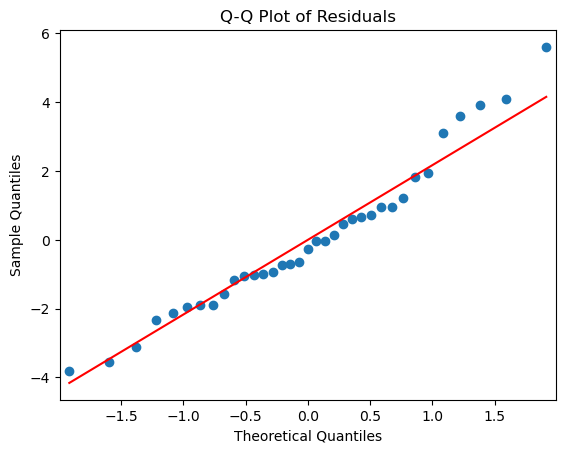

```
Shapiro-Wilk test statistic: 0.9628714919090271, p-value: 0.2783476710319519
Jarque-Bera test statistic: 2.102711171530069, p-value: 0.3494636998596139
```

```python
import statsmodels.api as sm
import matplotlib.pyplot as plt
from scipy.stats import shapiro, jarque_bera

# Fit the model
X = sm.add_constant(df1[['Price\n(in lakh rupees)','Mileage\n(Km/ltr)','Top speed (Km/hr)']])
model = sm.OLS(df1['Sales \n(in 1,000 units)'], X).fit()

# Get residuals
residuals = model.resid

# Q-Q plot
sm.qqplot(residuals, line='s')
plt.title('Q-Q Plot of Residuals')
plt.show()

# Shapiro-Wilk Test for normality
shapiro_test = shapiro(residuals)
print(f'Shapiro-Wilk test statistic: {shapiro_test.statistic}, p-value: {shapiro_test.pvalue}')

# Jarque-Bera test
jb_test = jarque_bera(residuals)
print(f'Jarque-Bera test statistic: {jb_test[0]}, p-value: {jb_test[1]}')
```

### INTERPRETATION - AS the p-value from these tests is > 0.05, the residuals are assumed to be normally distributed.

### Homoscedasticity (Constant Variance):

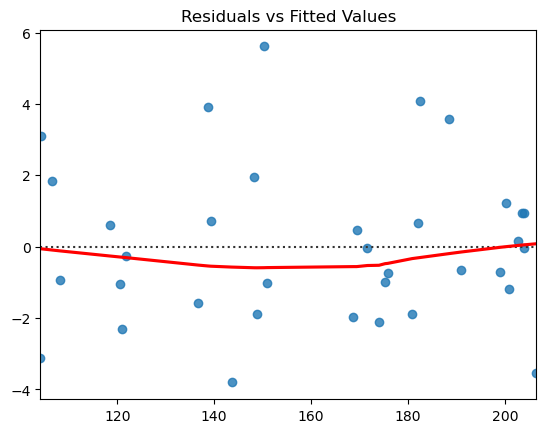

```
Breusch-Pagan test statistic: 1.788428345654001, p-value: 0.6174562893155564
```

```python
import seaborn as sns
from statsmodels.stats.diagnostic import het_breuschpagan

# Residuals vs. fitted values plot
fitted_values = model.fittedvalues
sns.residplot(x=fitted_values, y=residuals, lowess=True, line_kws={'color': 'red'})
plt.title('Residuals vs Fitted Values')
plt.show()

# Breusch-Pagan test
bp_test = het_breuschpagan(residuals, model.model.exog)
print(f'Breusch-Pagan test statistic: {bp_test[0]}, p-value: {bp_test[1]}')
```

### RESULT : For the Breusch-Pagan test, as the p-value is > 0.05, then homoscedasticity can be assumed.

### 2. Input Variables are Independent of Each Other (No Multicollinearity)

```python
from statsmodels.stats.outliers_influence import variance_inflation_factor

# Calculate VIF for each independent variable
vif_data = pd.DataFrame()
vif_data['feature'] = X.columns
vif_data['VIF'] = [variance_inflation_factor(X.values, i) for i in range(X.shape[1])]

print(vif_data)
```

[output not shown]

### 3. Successive Error Terms are Independent (No Autocorrelation)

[output not shown]

### RESULT: As Durbin-Watson statistic value is between 1.5 and 2.5 suggests no significant autocorrelation in the residuals.

### 4. Specification Bias (Correct Model Specification)

```python
from statsmodels.stats.outliers_influence import reset_ramsey

# Ramsey RESET test
reset_test = reset_ramsey(model, degree=3)
print(f'Ramsey RESET test statistic: {reset_test.fvalue}, p-value: {reset_test.pvalue}')
```

```
Ramsey RESET test statistic: 0.18007970511133498, p-value: 0.8361304418861777
```

### RESULT: As the p-value is > 0.05, the model is correctly specified

### Identify Outliers in Independent Variables (Leverage or Hat Diagonal)

```python
# Get the influence measures (hat diagonal)
influence = model.get_influence()
hat_values = influence.hat_matrix_diag

# Set a threshold for identifying high-leverage points (rule of thumb: 2*(k+1)/n, where k = number of predictors)
n = len(df)
k = X.shape[1] - 1  # number of predictors excluding the intercept
leverage_threshold = 2 * (k + 1) / n

# Identify high-leverage points
high_leverage_points = np.where(hat_values > leverage_threshold)[0]

print(f"High leverage points (outliers in X): {high_leverage_points}")
```

```
High leverage points (outliers in X): []
```

### Identify Outliers in Dependent Variables (Studentized Residuals)

```python
# Get the studentized residuals
studentized_residuals = influence.resid_studentized_external

# Set a threshold for identifying outliers in Y (commonly used threshold: |residual| > 3)
student_residuals_threshold = 3

# Identify outliers in the dependent variable
outliers_in_y = np.where(np.abs(studentized_residuals) > student_residuals_threshold)[0]

print(f"Outliers in Y (studentized residuals): {outliers_in_y}")
```

```
Outliers in Y (studentized residuals): []
```

### RESULT: NO Outliers in both dependent and independent variables

### Fitting Regression equation for Marengo Models

```python
df2
```

|  | Cars | Sales \n(in 1,000 units) | Price\n(in lakh rupees) | Mileage\n(Km/ltr) | Top speed (Km/hr) |
| --- | --- | --- | --- | --- | --- |
| 0 | Marengo 1 | 20.896 | 42.5 | 9.3 | 199.4 |
| 1 | Marengo 2 | 31.048 | 36.0 | 9.7 | 235.2 |
| 2 | Marengo 3 | 29.904 | 54.7 | 16.6 | 240.8 |
| 3 | Marengo 4 | 28.792 | 42.7 | 11.7 | 232.5 |
| 4 | Marengo 5 | 16.776 | 44.9 | 13.7 | 188.8 |
| 5 | Marengo 6 | 18.928 | 35.5 | 9.6 | 184.2 |
| 6 | Marengo 7 | 22.776 | 51.3 | 13.7 | 207.7 |
| 7 | Marengo 8 | 36.824 | 30.4 | 12.6 | 249.5 |
| 8 | Marengo 9 | 22.216 | 38.4 | 16.2 | 175.8 |
| 9 | Marengo 10 | 35.456 | 32.2 | 9.6 | 245.6 |
| 10 | Marengo 11 | 28.576 | 59.4 | 11.3 | 223.3 |
| 11 | Marengo 12 | 33.648 | 50.8 | 13.6 | 240.0 |
| 12 | Marengo 13 | 33.440 | 57.5 | 13.5 | 250.0 |
| 13 | Marengo 14 | 34.912 | 44.6 | 11.1 | 247.4 |
| 14 | Marengo 15 | 24.016 | 34.6 | 14.1 | 192.0 |
| 15 | Marengo 16 | 20.992 | 56.4 | 13.4 | 201.2 |
| 16 | Marengo 17 | 21.696 | 41.4 | 12.8 | 193.3 |
| 17 | Marengo 18 | 17.832 | 53.7 | 16.0 | 202.0 |
| 18 | Marengo 19 | 25.624 | 44.8 | 12.7 | 208.9 |
| 19 | Marengo 20 | 21.920 | 32.4 | 13.6 | 176.9 |
| 20 | Marengo 21 | 24.792 | 40.9 | 11.6 | 218.2 |
| 21 | Marengo 22 | 22.256 | 44.1 | 11.4 | 190.0 |
| 22 | Marengo 23 | 15.488 | 46.6 | 16.3 | 176.8 |
| 23 | Marengo 24 | 21.640 | 31.4 | 14.5 | 178.9 |
| 24 | Marengo 25 | 23.264 | 54.7 | 14.3 | 192.3 |
| 25 | Marengo 26 | 19.328 | 37.9 | 9.4 | 184.1 |
| 26 | Marengo 27 | 27.216 | 52.9 | 15.3 | 240.3 |
| 27 | Marengo 28 | 23.096 | 42.7 | 15.0 | 192.1 |
| 28 | Marengo 29 | 17.824 | 54.9 | 13.5 | 199.0 |
| 29 | Marengo 30 | 19.144 | 44.0 | 11.8 | 181.1 |
| 30 | Marengo 31 | 21.600 | 42.2 | 9.3 | 181.2 |

```python
list(df2)
```

```
['Cars',
 'Sales \n(in 1,000 units)',
 'Price\n(in lakh rupees)',
 'Mileage\n(Km/ltr)',
 'Top speed (Km/hr)']
```

```python
X = df2[['Price\n(in lakh rupees)','Mileage\n(Km/ltr)', 'Top speed (Km/hr)']]

# Add a constant term (intercept) to the model
X = sm.add_constant(X)

# Define the dependent variable (response)
y = df2['Sales \n(in 1,000 units)']

# Fit the regression model
model = sm.OLS(y, X).fit()

# Print the summary of the regression model
model.summary()
```

OLS Regression Results

| Dep. Variable: | Sales (in 1,000 units) | R-squared: | 0.863 |
| --- | --- | --- | --- |
| Model: | OLS | Adj. R-squared: | 0.848 |
| Method: | Least Squares | F-statistic: | 56.74 |
| Date: | Fri, 25 Oct 2024 | Prob (F-statistic): | 8.74e-12 |
| Time: | 21:44:51 | Log-Likelihood: | -67.757 |
| No. Observations: | 31 | AIC: | 143.5 |
| Df Residuals: | 27 | BIC: | 149.2 |
| Df Model: | 3 |  |  |
| Covariance Type: | nonrobust |  |  |

|  | coef | std err | t | P>\|t\| | [0.025 | 0.975] |
| --- | --- | --- | --- | --- | --- | --- |
| const | -13.4476 | 4.454 | -3.019 | 0.005 | -22.586 | -4.309 |
| Price (in lakh rupees) | -0.1867 | 0.055 | -3.368 | 0.002 | -0.300 | -0.073 |
| Mileage (Km/ltr) | 0.0413 | 0.207 | 0.200 | 0.843 | -0.383 | 0.465 |
| Top speed (Km/hr) | 0.2208 | 0.017 | 12.820 | 0.000 | 0.185 | 0.256 |

| Omnibus: | 2.082 | Durbin-Watson: | 1.649 |
| --- | --- | --- | --- |
| Prob(Omnibus): | 0.353 | Jarque-Bera (JB): | 1.181 |
| Skew: | -0.071 | Prob(JB): | 0.554 |
| Kurtosis: | 2.054 | Cond. No. | 2.30e+03 |

Notes:  
[1] Standard Errors assume that the covariance matrix of the errors is correctly specified.  
[2] The condition number is large, 2.3e+03. This might indicate that there are  
strong multicollinearity or other numerical problems.

```python
Sales= -13.4476 - 0.1867*41+ 0.0413*15 + 0.2208*210
print(Sales)
```

```
25.8852
```

### Regression equation : Sales= -13.4476 - 0.1867×Price+ 0.0413×Mileage + 0.2208×Top Speed

### Predicted sales for Marengo32 model is 25.8852 units

### but p-value of mileage is greater than 0.05, indicating that mileage is not a statistically significant predictor of sales at the 95% confidence level.

### Overall Significance:

##### The F-statistic of 56.74 is relatively high, suggesting that the regression model is a good fit for the data and indicates that the independent variables explain a significant amount of the variability in the dependent variable.

### Individual variable

##### Price and Top Speed are significant predictors of the dependent variable. Mileage is not significant, indicating it does not have a meaningful effect on the dependent variable in this model.

### Fitting the regression equation by conisdering price and top speed variables

```python
X = df2[['Price\n(in lakh rupees)', 'Top speed (Km/hr)']]

# Add a constant term (intercept) to the model
X = sm.add_constant(X)

# Define the dependent variable (response)
y = df2['Sales \n(in 1,000 units)']

# Fit the regression model
model = sm.OLS(y, X).fit()

# Print the summary of the regression model
model.summary()
```

OLS Regression Results

| Dep. Variable: | Sales (in 1,000 units) | R-squared: | 0.863 |
| --- | --- | --- | --- |
| Model: | OLS | Adj. R-squared: | 0.853 |
| Method: | Least Squares | F-statistic: | 88.10 |
| Date: | Fri, 25 Oct 2024 | Prob (F-statistic): | 8.30e-13 |
| Time: | 21:46:43 | Log-Likelihood: | -67.779 |
| No. Observations: | 31 | AIC: | 141.6 |
| Df Residuals: | 28 | BIC: | 145.9 |
| Df Model: | 2 |  |  |
| Covariance Type: | nonrobust |  |  |

|  | coef | std err | t | P>\|t\| | [0.025 | 0.975] |
| --- | --- | --- | --- | --- | --- | --- |
| const | -12.9701 | 3.694 | -3.511 | 0.002 | -20.536 | -5.404 |
| Price (in lakh rupees) | -0.1825 | 0.050 | -3.627 | 0.001 | -0.286 | -0.079 |
| Top speed (Km/hr) | 0.2201 | 0.017 | 13.254 | 0.000 | 0.186 | 0.254 |

| Omnibus: | 2.394 | Durbin-Watson: | 1.650 |
| --- | --- | --- | --- |
| Prob(Omnibus): | 0.302 | Jarque-Bera (JB): | 1.258 |
| Skew: | -0.059 | Prob(JB): | 0.533 |
| Kurtosis: | 2.020 | Cond. No. | 1.94e+03 |

Notes:  
[1] Standard Errors assume that the covariance matrix of the errors is correctly specified.  
[2] The condition number is large, 1.94e+03. This might indicate that there are  
strong multicollinearity or other numerical problems.

### Regression Equation: Sales = -12.9701 -0.1825(price) + 0.2201(top speed)

### Overall Significance:

##### The F-statistic of 88.10 suggests that the regression model explains a significant amount of the variability in the dependent variable. A higher F-statistic indicates a stronger relationship between the dependent variable and the independent variables.

### Individual variable

##### Significant Variables: Both Price and Top Speed are significant predictors of the dependent variable. Intercept: The intercept is also significant and indicates the baseline level of the dependent variable.

```python
#if price = 41 lakhs and top speed = 210 km/hr
Sales  = -12.9701 -0.1825* 41 + 0.2201 * 210
print(Sales)
```

```
25.768399999999996
```

### Sales of Marengo 32 = 25.768399999999996\n(in 1,000 units)

### c) Increase the input values by 5% and check the sales

```python
# Sales= -13.4476 - 0.1867×Price+ 0.0413×Mileage + 0.2208×Top Speed
price = 41 * 1.05
mileage = 15* 1.05
speed = 210 * 1.05
print(price)
print(mileage)
print(speed)
```

```
43.050000000000004
15.75
220.5
```

```python
Sales= -13.4476 - 0.1867 * 43.050000000000004 + 0.0413 * 15.75  + 0.2208 * 220.5
print(Sales)
```

```
27.85184
```

### Predicted Sales of Marengo 32 if input is increased by 5% = 27.85184\n(in 1,000 units)

### d) Decrease the input values by 5% and check the sales

```python
# Sales= -13.4476 - 0.1867×Price+ 0.0413×Mileage + 0.2208×Top Speed
price = 41 * 0.95
mileage = 15* 0.95
speed = 210 * 0.95
print(price)
print(mileage)
print(speed)
```

```
38.949999999999996
14.25
199.5
```

```python
Sales= -13.4476 - 0.1867 * 38.949999999999996 + 0.0413 * 14.25 + 0.2208 * 199.5
print(Sales)
```

```
23.91856
```

### Predicted Sales of Marengo 32 if input is decreased by 5% = 23.91856\n(in 1,000 units)

### 1. Error term is normally distributed with mean 0 and constant variance

### a.Normality of Residuals (Mean 0):

```python
list(df2)
```

```
['Cars',
 'Sales \n(in 1,000 units)',
 'Price\n(in lakh rupees)',
 'Mileage\n(Km/ltr)',
 'Top speed (Km/hr)']
```

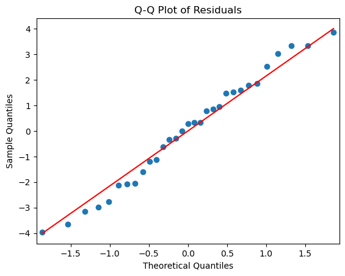

```
Shapiro-Wilk test statistic: 0.9717198014259338, p-value: 0.5675449371337891
Jarque-Bera test statistic: 1.1811473023479762, p-value: 0.5540093854272187
```

```python
import statsmodels.api as sm
import matplotlib.pyplot as plt
from scipy.stats import shapiro, jarque_bera

# Fit the model
X = sm.add_constant(df2[['Price\n(in lakh rupees)','Mileage\n(Km/ltr)','Top speed (Km/hr)']])
model = sm.OLS(df2['Sales \n(in 1,000 units)'], X).fit()

# Get residuals
residuals = model.resid

# Q-Q plot
sm.qqplot(residuals, line='s')
plt.title('Q-Q Plot of Residuals')
plt.show()

# Shapiro-Wilk Test for normality
shapiro_test = shapiro(residuals)
print(f'Shapiro-Wilk test statistic: {shapiro_test.statistic}, p-value: {shapiro_test.pvalue}')

# Jarque-Bera test
jb_test = jarque_bera(residuals)
print(f'Jarque-Bera test statistic: {jb_test[0]}, p-value: {jb_test[1]}')
```

### RESULT - AS the p-value from these tests is > 0.05, the residuals are assumed to be normally distributed.

### b. Homoscedasticity (Constant Variance):

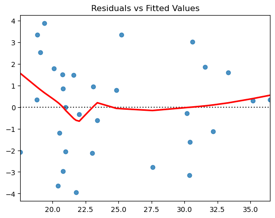

```
Breusch-Pagan test statistic: 7.394947338592948, p-value: 0.060320039874716125
```

```python
# Residuals vs. fitted values plot
fitted_values = model.fittedvalues
sns.residplot(x=fitted_values, y=residuals, lowess=True, line_kws={'color': 'red'})
plt.title('Residuals vs Fitted Values')
plt.show()

# Breusch-Pagan test
bp_test = het_breuschpagan(residuals, model.model.exog)
print(f'Breusch-Pagan test statistic: {bp_test[0]}, p-value: {bp_test[1]}')
```

### RESULT : For the Breusch-Pagan test, as the p-value is > 0.05, then homoscedasticity can be assumed.

### 2. Input Variables are Independent of Each Other (No Multicollinearity)

```python
# Calculate VIF for each independent variable
vif_data = pd.DataFrame()
vif_data['feature'] = X.columns
vif_data['VIF'] = [variance_inflation_factor(X.values, i) for i in range(X.shape[1])]

print(vif_data)
```

```
                   feature         VIF
0                    const  115.565519
1  Price\n(in lakh rupees)    1.232176
2        Mileage\n(Km/ltr)    1.184425
3        Top speed (Km/hr)    1.090848
```

### RESULT: AS VIF value of all the variables are < 5, there is no exist of multicolinearity

### 3. Successive Error Terms are Independent (No Autocorrelation)

```python
# Durbin-Watson test for autocorrelation
dw_stat = durbin_watson(residuals)
print(f'Durbin-Watson statistic: {dw_stat}')
```

```
Durbin-Watson statistic: 1.649289430373181
```

### RESULT: As Durbin-Watson statistic value is between 1.5 and 2.5 suggests no significant autocorrelation in the residuals.

### 4. Specification Bias (Correct Model Specification)

```python
from statsmodels.stats.outliers_influence import reset_ramsey

# Ramsey RESET test
reset_test = reset_ramsey(model, degree=3)
print(f'Ramsey RESET test statistic: {reset_test.fvalue}, p-value: {reset_test.pvalue}')
```

```
Ramsey RESET test statistic: 0.39196911930685996, p-value: 0.6798051582842259
```

### RESULT: As the p-value is > 0.05, the model is correctly specified.

### Identify Outliers in Independent Variables (Leverage or Hat Diagonal)

```python
# Get the influence measures (hat diagonal)
influence = model.get_influence()
hat_values = influence.hat_matrix_diag

# Set a threshold for identifying high-leverage points (rule of thumb: 2*(k+1)/n, where k = number of predictors)
n = len(df)
k = X.shape[1] - 1  # number of predictors excluding the intercept
leverage_threshold = 2 * (k + 1) / n

# Identify high-leverage points
high_leverage_points = np.where(hat_values > leverage_threshold)[0]

print(f"High leverage points (outliers in X): {high_leverage_points}")
```

```
High leverage points (outliers in X): []
```

### Identify Outliers in Dependent Variables (Studentized Residuals)

```python
# Get the studentized residuals
studentized_residuals = influence.resid_studentized_external

# Set a threshold for identifying outliers in Y (commonly used threshold: |residual| > 3)
student_residuals_threshold = 3

# Identify outliers in the dependent variable
outliers_in_y = np.where(np.abs(studentized_residuals) > student_residuals_threshold)[0]

print(f"Outliers in Y (studentized residuals): {outliers_in_y}")
```

```
Outliers in Y (studentized residuals): []
```

### RESULT: No outliers in both dependent and indepentdent variable

### Q-5) Based on the sales prediction, calculate the overall projected profit for the Rocinante36 and Marengo32 models, respectively?

```python
selling_price_roc36 = 700000
cost_per_unit_roc36 = 600000
selling_price_mar32 = 4100000
cost_per_unit_mar32 = 3300000
pred_sales_roc36 = 225.2927
pred_sales_mar32 = 25.8439

# Calculate profits for each model
profit_roc36 = (selling_price_roc36 - cost_per_unit_roc36) * pred_sales_roc36
profit_mar32 = (selling_price_mar32 - cost_per_unit_mar32) * pred_sales_mar32

print(f"Overall Projected Profit for Rocinante36: {profit_roc36}")
print(f"Overall Projected Profit for Marengo32: {profit_mar32}")
```

```
Overall Projected Profit for Rocinante36: 22529270.0
Overall Projected Profit for Marengo32: 20675120.0
```

### Q-6) Your company wishes to invest only in the model that can generate high overall profits. In which of the two models, Rocinante36 and Marengo32, should your company invest?

### Decision:

#### Rocinante36 is the better investment option based on the projected profit figures.

### Q-7) You must have developed the regression equation for both the models, Rocinante36 and Marengo32. Suppose you increase the price of Rocinante36 and Marengo32 by ₹1 lakh each. Which of the two models will have to see a higher impact on sales numbers? Provide proper logic for your answer. (Note: You can assume that all the other specifications, such as mileage and top speed, are the same for both models.)

```python
#Regression equation for Rocinante36 : Sales=50.7231−0.7950×Price+8.3063×Mileage−0.0186×Top Speed
# Regression equation  for Marengo32 : Sales= -13.4476 - 0.1867×Price+ 0.0413×Mileage + 0.2208×Top Speed
# IF the price increase by 1lakh
Sales_Roc36= 50.7231 - 0.7950 * 8 +8.3063 * 22 - 0.0186*140
Sales_Mar32 = -13.4476 - 0.1867 * 42 + 0.0413 * 14+ 0.2208 *210
print(f" Predicted sales after increase in price for Rocinante36: {Sales_Roc36}")
print(f" Predicted sales after increase in price for Marengo32: {Sales_Mar32}")
```

```
 Predicted sales after increase in price for Rocinante36: 224.4977
 Predicted sales after increase in price for Marengo32: 25.6572
```

### RESULT: The impact of increasing the price on sales is more pronounced in Rocinante36, indicating that customers may be more price-sensitive for this model.

### Q-8) After developing the regression equation for both the models (Rocinante36 and Marengo32), if you analyse the p-values for the coefficients in the regression results, you will notice that some of the regression variables (top speed, mileage and price) are insignificant. Drop the insignificant regression variables and rebuild the regression model using only significant variables.Compare the adjusted R-squared value for both the new and the old regression models. Do you notice any change in the adjusted R-squared value? If yes, explain the reason for the change.

#### adjusted R Sqaure value of Rocinante36 model before and removing insignificant variables: 0.995 and 0.995 respectively

#### adjusted R Sqaure value of Marengo32 model before and removing insignificant variables: 0.848 and 0.853 respectively

#### RESULT: In the Rocinante36 model, the adjusted R-squared value did not change, suggesting the insignificant variables had no substantial impact on the model's performance.

#### In the Marengo32 model, the adjusted R-squared value increased, indicating that the significant variables were more effective at explaining the variation in the dependent variable without the presence of insignificant variables.